# Relative healthcare use (Albuminuria with eGFR >60)

Blood pressure measurements (overall)

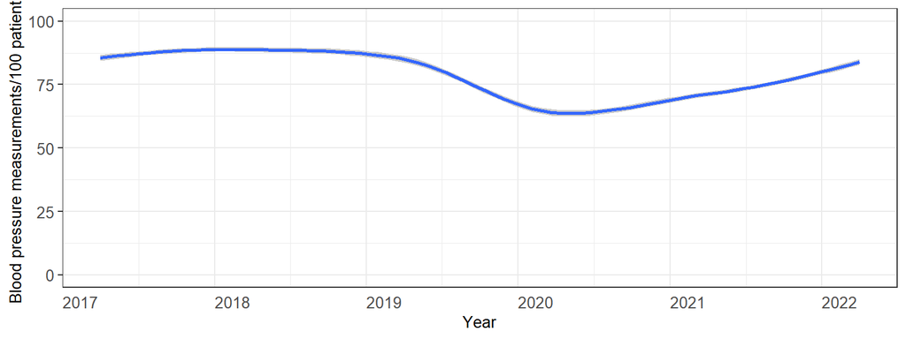

Blood pressure measurements by ethnicity

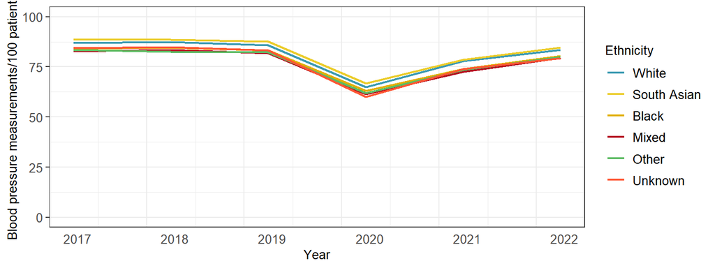

Blood pressure measurements by IMD

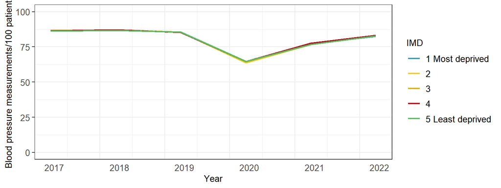

Blood pressure measurements by region

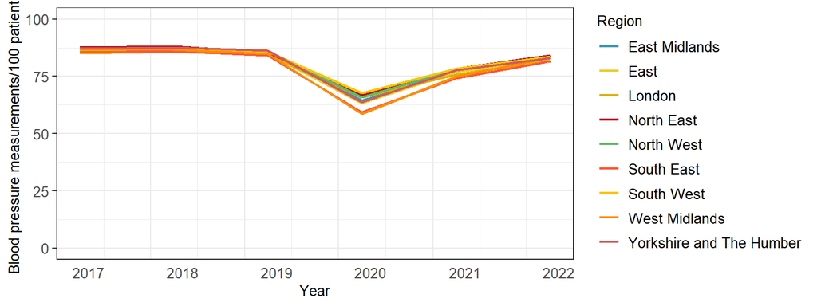

Blood pressure measurements by rural/urban

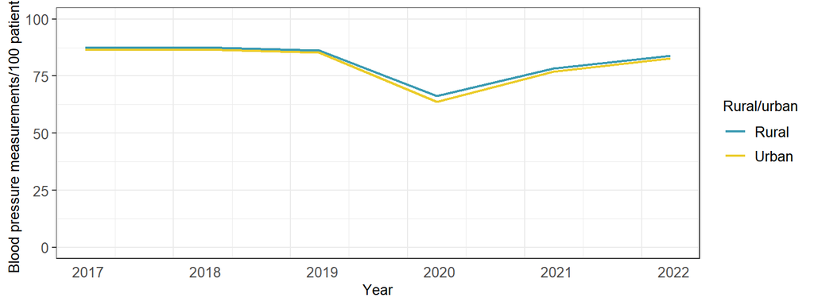

**uACR measurements**

uACR measurements (overall)

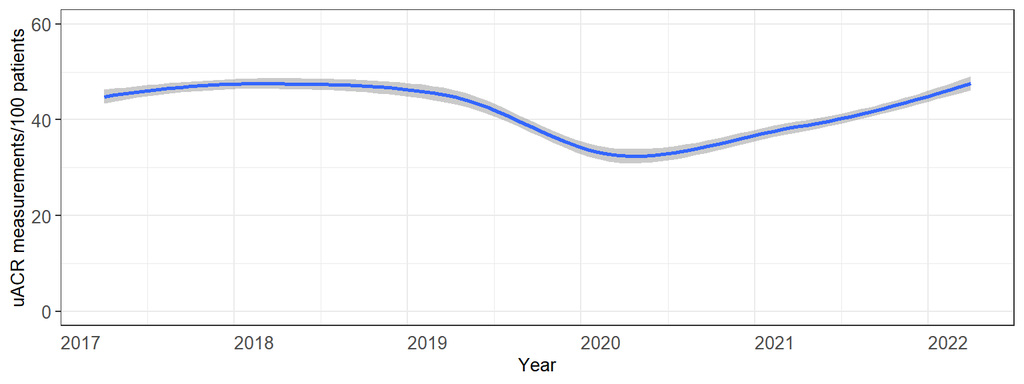

uACR measurements by ethnicity

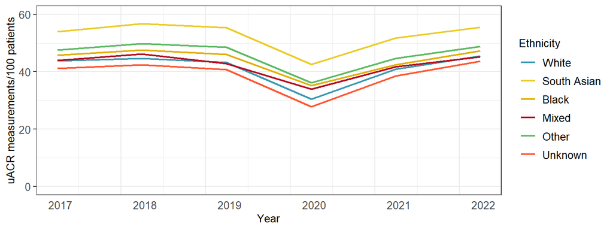

uACR measurements by IMD

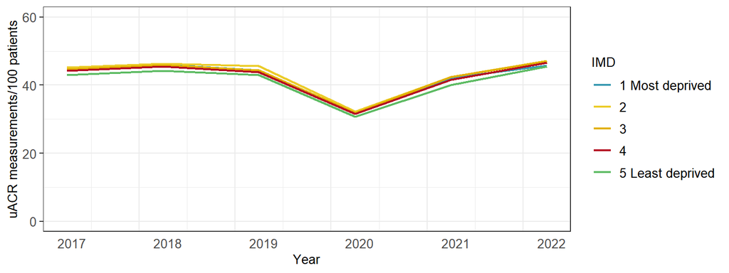

uACR measurements by region

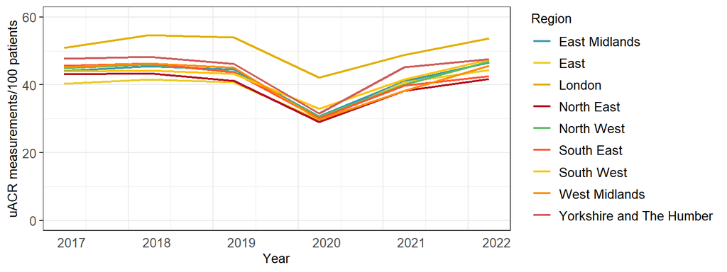

uACR measurements by rural/urban

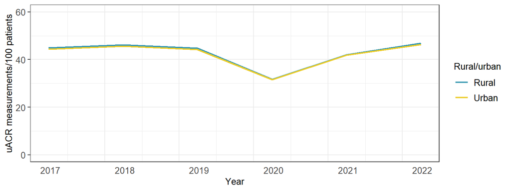

**SCr measurements**

SCr measurements (overall)

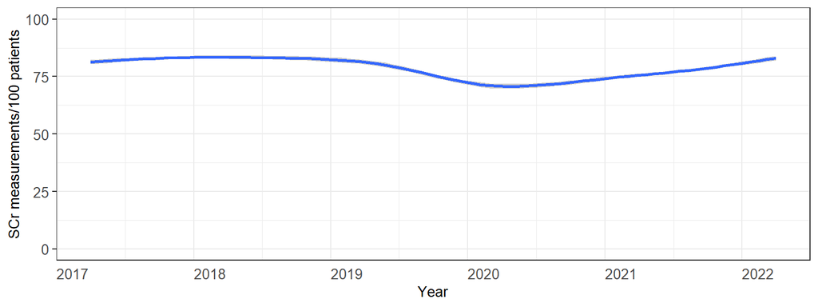

SCr measurements by ethnicity

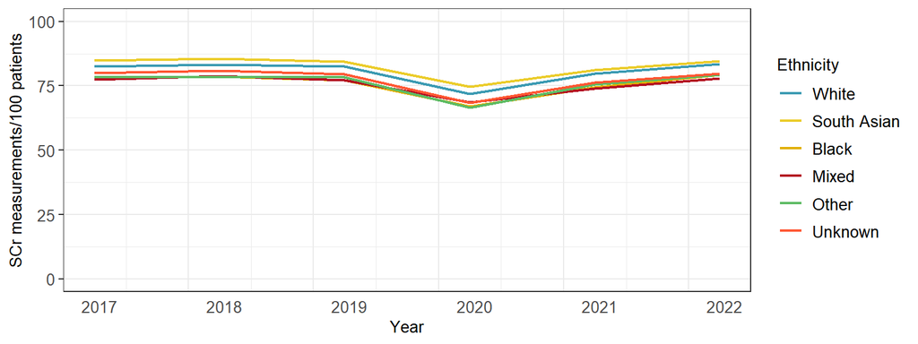

SCr measurements by IMD

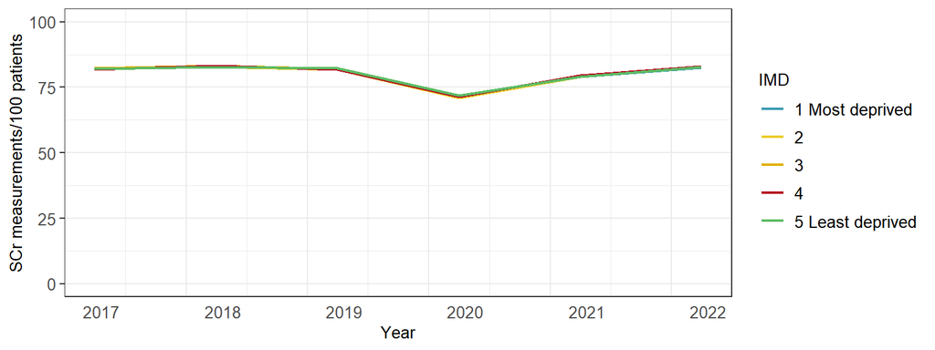

SCr measurements by region

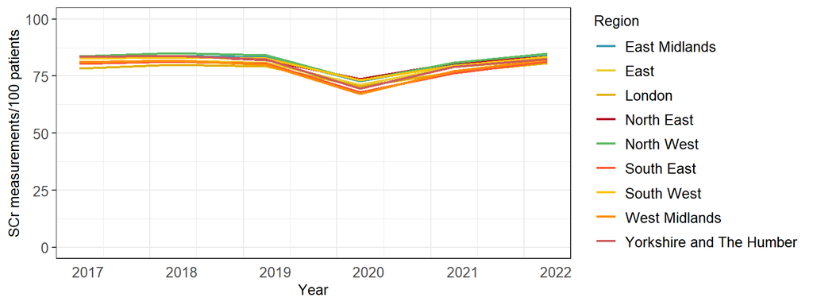

SCr measurements by rural/urban

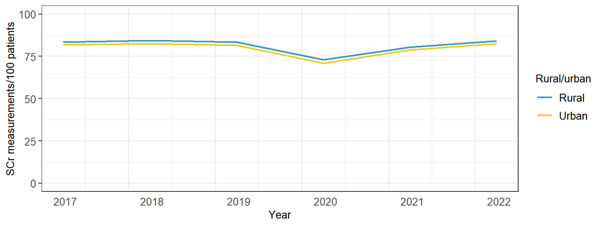